# Recognition of Weight Lifting

Peng Wu

May 18, 2017

## Executive Summary

In this project, we try to predicted 5 different way of weitght lifting using machine learning algrithms. The data set used here is from http://groupware.les.inf.puc-rio.br/har (see the section on the Weight Lifting Exercise Dataset). We peformed some data preprocessing ,feature selection and model selection. The best model we found is knn. The accuracy rate is 99%.

## Download and Loading data

```r
library(caret)
library(ggplot2)

trainRaw <- read.csv("./pml-training.csv",na.string=c("#DIV/0!","NA"))
testRaw <- read.csv("./pml-testing.csv",na.string=c("#DIV/0!","NA"))
```

## Data Preprocessing

```r
dim(trainRaw)
```

```
## [1] 19622   160
```

We found thar There 160 variables in each observation, which is very large. We should consider reducing the number of varibles.

First, we found that the first 7 columns seems irelevant to the outcome.

```r
names(trainRaw[1:7])
```

```
## [1] "X"                    "user_name"            "raw_timestamp_part_1"
## [4] "raw_timestamp_part_2" "cvtd_timestamp"       "new_window"
## [7] "num_window"
```

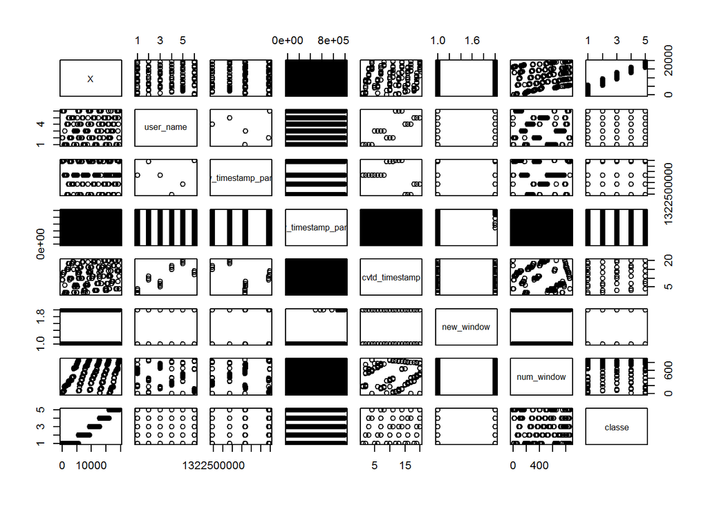

```r
plot(trainRaw[c(1:7,160)])
```

Looking at the plot we found that only X have a clear impact on classe. But X is only a sequence number, so it should be removed also.

```r
irelevantVar <-c(1:7)
```

Another issue is that there are a lot of variables do not have any value at all in the testing data set. Since we are not getting these input at all, I think we are safe to remove them.

```r
nullCol <- which(colSums(!is.na(testRaw))==0)
removedCol <- c(irelevantVar,nullCol)
training <- trainRaw[,-removedCol]
testing <- testRaw[,-removedCol]
```

## Data Slicing

Reserve some data for validation purpose.

```r
set.seed(456)
inTrain <- createDataPartition(training$classe, p = .70, list = FALSE)
trainPart <- training[inTrain,]
validPart <- training[-inTrain,]
```

## Reducing Dimesions

Use PCA method to reduce the number of dimesions.

```r
prePro <- preProcess(trainPart, method = "pca" ,thresh = 0.8)
trainPartPC <- predict(prePro, trainPart)
validPartPC <- predict(prePro, validPart)
```

## Model Training

We choose k-Nearest Neighbors and Bagged CART to bulid our model. For each algrithm, we build two models, with or without PCA preprocessing.

### k-Nearest Neighbors

#### k-NN with PCA

```r
kknnPC <- train(classe ~., trainPartPC, method = "kknn")
kknnPCPred <- predict(kknnPC, validPartPC)
cmkknnPC <- confusionMatrix(kknnPCPred,validPart$classe)
cmkknnPC
```

```
## Confusion Matrix and Statistics
##
##           Reference
## Prediction    A    B    C    D    E
##          A 1647   11    6    1    1
##          B   13 1091   10    3    9
##          C    7   30  981   19    8
##          D    7    2   25  940    5
##          E    0    5    4    1 1059
##
## Overall Statistics
##
##                Accuracy : 0.9716
##                  95% CI : (0.9671, 0.9757)
##     No Information Rate : 0.2845
##     P-Value [Acc > NIR] : <2e-16
##
##                   Kappa : 0.9641
##  Mcnemar's Test P-Value : 0.0156
##
## Statistics by Class:
##
##                      Class: A Class: B Class: C Class: D Class: E
## Sensitivity            0.9839   0.9579   0.9561   0.9751   0.9787
## Specificity            0.9955   0.9926   0.9868   0.9921   0.9979
## Pos Pred Value         0.9886   0.9689   0.9388   0.9602   0.9906
## Neg Pred Value         0.9936   0.9899   0.9907   0.9951   0.9952
## Prevalence             0.2845   0.1935   0.1743   0.1638   0.1839
## Detection Rate         0.2799   0.1854   0.1667   0.1597   0.1799
## Detection Prevalence   0.2831   0.1913   0.1776   0.1664   0.1816
## Balanced Accuracy      0.9897   0.9752   0.9715   0.9836   0.9883
```

#### k-NN without PCA

```r
kknn <- train(classe ~., trainPart, method = "kknn")
kknnPred <- predict(kknn, validPart)
cmkknn <- confusionMatrix(kknnPred,validPart$classe)
cmkknn
```

```
## Confusion Matrix and Statistics
##
##           Reference
## Prediction    A    B    C    D    E
##          A 1665    4    0    1    0
##          B    7 1124    6    2    4
##          C    0    9 1010    5    1
##          D    2    1   10  955    2
##          E    0    1    0    1 1075
##
## Overall Statistics
##
##                Accuracy : 0.9905
##                  95% CI : (0.9877, 0.9928)
##     No Information Rate : 0.2845
##     P-Value [Acc > NIR] : < 2.2e-16
##
##                   Kappa : 0.988
##  Mcnemar's Test P-Value : NA
##
## Statistics by Class:
##
##                      Class: A Class: B Class: C Class: D Class: E
## Sensitivity            0.9946   0.9868   0.9844   0.9907   0.9935
## Specificity            0.9988   0.9960   0.9969   0.9970   0.9996
## Pos Pred Value         0.9970   0.9834   0.9854   0.9845   0.9981
## Neg Pred Value         0.9979   0.9968   0.9967   0.9982   0.9985
## Prevalence             0.2845   0.1935   0.1743   0.1638   0.1839
## Detection Rate         0.2829   0.1910   0.1716   0.1623   0.1827
## Detection Prevalence   0.2838   0.1942   0.1742   0.1648   0.1830
## Balanced Accuracy      0.9967   0.9914   0.9907   0.9938   0.9966
```

### Bagged CART

#### Bagged CART PCA

```r
treebagPC <- train(classe ~., trainPartPC, method = "treebag")
treebagPCPred <- predict(treebagPC, validPartPC)
cmtreebagPC <- confusionMatrix(treebagPCPred,validPart$classe)
cmtreebagPC
```

```
## Confusion Matrix and Statistics
##
##           Reference
## Prediction    A    B    C    D    E
##          A 1587   38   24   34    7
##          B   28 1048   21    5   22
##          C   24   41  947   36   16
##          D   30    7   29  880   15
##          E    5    5    5    9 1022
##
## Overall Statistics
##
##                Accuracy : 0.9319
##                  95% CI : (0.9251, 0.9382)
##     No Information Rate : 0.2845
##     P-Value [Acc > NIR] : < 2.2e-16
##
##                   Kappa : 0.9138
##  Mcnemar's Test P-Value : 0.002089
##
## Statistics by Class:
##
##                      Class: A Class: B Class: C Class: D Class: E
## Sensitivity            0.9480   0.9201   0.9230   0.9129   0.9445
## Specificity            0.9755   0.9840   0.9759   0.9835   0.9950
## Pos Pred Value         0.9391   0.9324   0.8900   0.9157   0.9771
## Neg Pred Value         0.9793   0.9809   0.9836   0.9829   0.9876
## Prevalence             0.2845   0.1935   0.1743   0.1638   0.1839
## Detection Rate         0.2697   0.1781   0.1609   0.1495   0.1737
## Detection Prevalence   0.2872   0.1910   0.1808   0.1633   0.1777
## Balanced Accuracy      0.9618   0.9520   0.9495   0.9482   0.9698
```

```r
treebag <- train(classe ~., trainPart, method = "treebag")
treebagPred <- predict(treebag, validPart)
cmtreebag <- confusionMatrix(treebagPred,validPart$classe)
cmtreebag
```

```
## Confusion Matrix and Statistics
##
##           Reference
## Prediction    A    B    C    D    E
##          A 1661   10    0    2    0
##          B   10 1114   19    3    1
##          C    1   14  996   11    4
##          D    2    0    9  946    0
##          E    0    1    2    2 1077
##
## Overall Statistics
##
##                Accuracy : 0.9845
##                  95% CI : (0.981, 0.9875)
##     No Information Rate : 0.2845
##     P-Value [Acc > NIR] : < 2.2e-16
##
##                   Kappa : 0.9804
##  Mcnemar's Test P-Value : NA
##
## Statistics by Class:
##
##                      Class: A Class: B Class: C Class: D Class: E
## Sensitivity            0.9922   0.9781   0.9708   0.9813   0.9954
## Specificity            0.9972   0.9930   0.9938   0.9978   0.9990
## Pos Pred Value         0.9928   0.9712   0.9708   0.9885   0.9954
## Neg Pred Value         0.9969   0.9947   0.9938   0.9963   0.9990
## Prevalence             0.2845   0.1935   0.1743   0.1638   0.1839
## Detection Rate         0.2822   0.1893   0.1692   0.1607   0.1830
## Detection Prevalence   0.2843   0.1949   0.1743   0.1626   0.1839
## Balanced Accuracy      0.9947   0.9855   0.9823   0.9895   0.9972
```

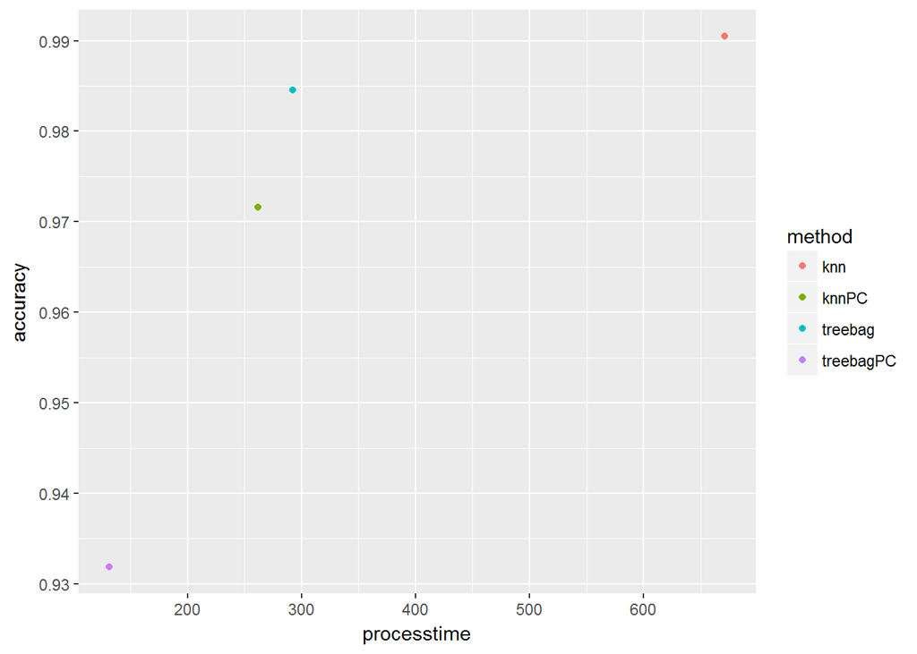

```r
method <- c('knn','knnPC','treebag','treebagPC')
accuracy <- c(cmkknn$overall[1],
              cmkknnPC$overall[1],
              cmtreebag$overall[1],
              cmtreebagPC$overall[1])
processtime <- c(kknn$times$everything[3],
                 kknnPC$times$everything[3],
                 treebag$times$everything[3],
                 treebagPC$times$everything[3])
modelCompare <- data.frame(method = method, accuracy = accuracy, processtime = processtime)

g <- ggplot(data = modelCompare, aes(x = processtime, y = accuracy,color = method))
g + geom_point()
```

We can see that the knn without PCA model gives the highest accuarcy and its processing time is also acceptable. Thus, we choose knn as the final model.

## Prediction

```r
data.frame(testing[53],prediction=predict(kknn,testing))
```

```
##    problem_id prediction
## 1           1          B
## 2           2          A
## 3           3          B
## 4           4          A
## 5           5          A
## 6           6          E
## 7           7          D
## 8           8          B
## 9           9          A
## 10         10          A
## 11         11          B
## 12         12          C
## 13         13          B
## 14         14          A
## 15         15          E
## 16         16          E
## 17         17          A
## 18         18          B
## 19         19          B
## 20         20          B
```